# Calibrated-𝛿 Multiple Imputation

# Welcome!

This R Markdown file recreates the simulation study of calibrated-$\delta$ multiple imputation, based on the paper “Population-calibrated multiple imputation for a binary/categorical covariate in categorical regression models” by Pham et al. Throughout this document, I will refer to Pham et al.’s paper as simply “the paper”.

This file begins with background information on the set up of the simulation, followed by a walk-through of each step in the calibrated-$\delta$ algorithm. To see the finished code, jump ahead to “Helper Functions” and “Simulation Code” using the menu on the left.

# Set Up

The simulation study is described in Section 3.1.1 of the paper.

1. Simulate $n = 5000$ complete values of the binary 0/1 covariate $x$ and binary 0/1 outcome $y$ from the following models.

$$x \sim \text{Bernoulli}(p_x^{pop} = 0.7);$$
$$\text{logit}[p(y = 1 | x)] = \beta_0 + \beta_x x,$$

where $\beta_0$ and $\beta_x$ are arbitrarily set to $ln(0.5)$ and $ln(1.5)$, respectively. The same values of the $\beta$ parameters are used throughout to make bias comparable across all simulation settings. This sample size is chosen to minimize the issue of small-sample bias associated with logistic regression.

Load the packages we’ll need

```r
library(knitr)
library(ggplot2)
library(ggthemes)
library(locfit) #used for expit function
library(mice)
library(dplyr)
library(tidyverse)
library(dplyr)
library(purrr)
library(xtable)
library(cowplot)
```

Generate the data:

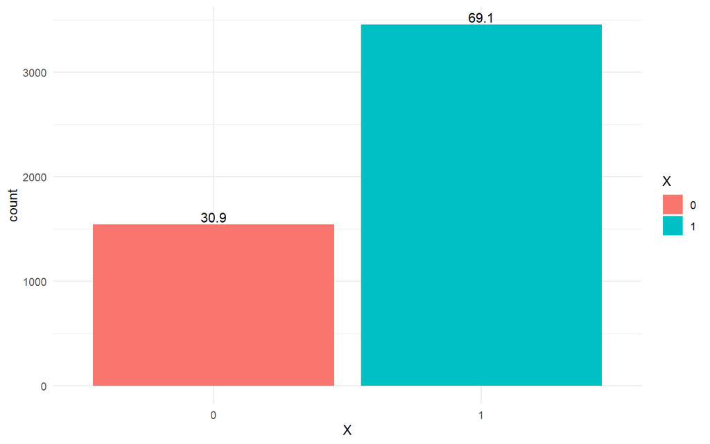

```r
n = 5000
pop_x = 0.7

#simulate the x values
X = rbinom(n, size = 1, pop_x)

#simulate the y values
beta_0 = log(0.5)
beta_x = log(1.5)
Y = rbinom(n, size = 1, prob = expit(beta_0 + beta_x * X))

#combine results into a data frame
completeData = data.frame(X, Y)

#convert X and Y columns to factors
completeData$X = as.factor(completeData$X)
completeData$Y = as.factor(completeData$Y)

#see if the sample of x values is distributed approximately as expected
ggplot(data = completeData, aes(x = X)) +
  geom_bar(aes(fill = X)) +
  geom_text(
    aes(label = after_stat(prop*100), group = 1, vjust = -0.25),
    stat = 'count'
  ) +
  theme_minimal()
```

```r
#another way of viewing the distribution of X and Y
table(completeData)
```

```
##    Y
## X      0    1
##   0 1041  504
##   1 2002 1453
```

This table summarizes the joint probability of $x$ and $y$:

|  | $y = 0$ | $y = 1$ |  |
| --- | --- | --- | --- |
| $x = 0$ | $0.3(1 - \text{expit}(ln(0.5) + ln(1.5)*0)) = 0.2$ | $0.3(\text{expit}(ln(0.5) + ln(1.5)*0)) = 0.1$ | $p(x = 0) = 0.3$ |
| $x = 1$ | $0.7(1 - \text{expit}(ln(0.5) + ln(1.5)*1)) = 0.4$ | $0.7(\text{expit}(ln(0.5) + ln(1.5)*1)) = 0.3$ | $p(x = 1) = 0.7$ |
|  | $p(y = 0) = 0.6$ | $p(y = 1) = 0.4$ |  |

# Missingness Mechanisms

2. Simulate a binary indicator of response $r$ of $x$ from each of the selection models M1 to M4 (Table 1C). Values of 1.5 and -1.5 are chosen for $\alpha_y$ and $\alpha_x$ in M2 and M3, respectively, to reflect strong odds ratios ($OR$s) of observing $x$ ($OR = 4.5$ and $0.2$, respectively). For M4, $\alpha_y = 1.5$ and $\alpha_x = -1.5$ are chosen as bias in the two MI methods under evaluation is likely to be apparent with these coefficients predicting missingness in $x$. For all selection models, $\alpha_0$ is altered to achieve approximately 45% missing $x$. For M1, $\alpha_0$ is calculated directly as $ln(\frac{0.55}{0.45})$; for M2 to M4, $\alpha_0 = -0.2; 1.35$ and $0.75$ appear to work well.

That is, $\text{logit}[p(r = 1 | x, y)] = \alpha_0 + \alpha_y y + \alpha_x x$, with the following parameter values used for this simulation study:

| Missingness Mechanism/Parameter Value | $\alpha_0$ | $\alpha_y$ | $\alpha_x$ |
| --- | --- | --- | --- |
| M1 | ln(0.55/0.45) | 0 | 0 |
| M2 | -0.2 | 1.5 | 0 |
| M3 | 1.35 | 0 | -1.5 |
| M4 | 0.75 | 1.5 | -1.5 |

Each of the 4 missingness mechanisms is explored further in the tabs below.

## M1

Note that in M1, missingness in $x$ occurs randomly; the value of $x$ and $y$ do not affect the probability that x is missing. That is, M1 simulates data missing completely at random (MCAR).  
Under M1, $r \sim \text{Bernoulli}(p = 0.55)$, and therefore $E[r] = 0.55$ and $Var[p] = 0.55*0.45 = 0.2475$. We can approximate a 95% confidence interval for $\bar r$, which is the proportion of missing $x$ values in the sample of 5000. That is, $0.55 \pm 1.96 \sqrt{0.2475/5000} = (0.536, 0.564)$ is a 95% CI for $\bar r$.

## M2

In M2, missingness in $x$ is related to the value of $y$. Specifically, if $y$ is 0, the probability that $x$ is observed is $\text{expit} (-0.2 + 1.5*0) \approx 0.450$. If $y$ is 1, the probability that $x$ is observed is $\text{expit} (-0.2 + 1.5*1) \approx 0.786$. In this mechanism, $x$ is missing at random (MAR) conditional on $y$. I.e., if we know the value of $y$, missingness in $x$ occurs at random. Under M2, $r|y \sim \text{Bernoulli}(p = \text{expit}(-0.2 + 1.5 y))$.
$$\begin{aligned}
E[r|y] &= \text{expit}(-0.2 + 1.5y) \\
\end{aligned}$$
By the law of iterated expectations:
$$\begin{aligned}
E[r] &= E[E[r|y]] \\
&= E[\text{expit}(-0.2 + 1.5y)] \\
&= \text{expit}(-0.2 + 1.5*0)*p(y = 0) + \text{expit}(-0.2 + 1.5*1)*p(y = 1) \\
&= \text{expit}(-0.2 + 1.5*0)*0.6 + \text{expit}(-0.2 + 1.5*1)*0.4 \\
&\approx 0.584
\end{aligned}$$

```r
expit(-0.2 + 1.5*0)*0.6 + expit(-0.2 + 1.5*1)*0.4
```

```
## [1] 0.5844336
```

By the conditional variance identity:
$$\begin{aligned}
Var[r] &= E[Var[r|y]] + Var[E[r|y]] \\
&= E[\text{expit}(-0.2 + 1.5y)(1 - \text{expit}(-0.2 + 1.5y))] + Var[\text{expit}(-0.2 + 1.5y)] \\
&= E[\text{expit}(-0.2 + 1.5y)] - E[(\text{expit}(-0.2 + 1.5y))^2] + E[(\text{expit}(-0.2 + 1.5y))^2] - (E[\text{expit}(-0.2 + 1.5y)])^2 \\
&= E[\text{expit}(-0.2 + 1.5y)] - (E[\text{expit}(-0.2 + 1.5y)])^2 \\
&\approx 0.584 - 0.584^2 \\
&\approx 0.243
\end{aligned}$$

We can approximate a 95% confidence interval for $\bar r$, which is the proportion of missing $x$ values in the sample of 5000. That is, $0.584 \pm 1.96 \sqrt{0.243/5000} = (0.570, 0.598)$ is a 95% CI for $\bar r$.  
That is, for every 100 data sets of size 5000 generated randomly under M2, we would expect that 95 of them would contain between 57.0% and 59.8% observed $x$. We can check this with a simulation:

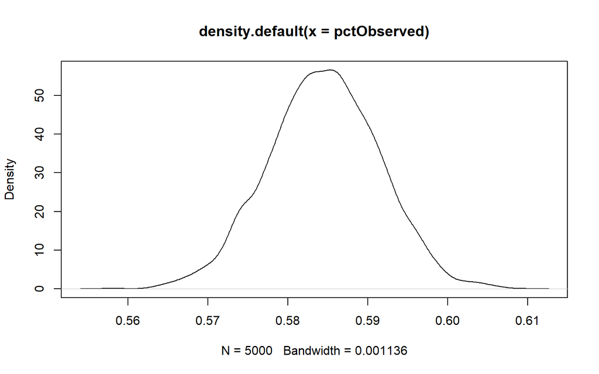

```r
#find CI for r under the M2 mechanism via simulation.

S = 5000
pctObserved = matrix(nrow = S, ncol = 1)

for (i in 1:S) {
  n = 5000
  pop_x = 0.7

  #simulate the x values
  X = rbinom(n, size = 1, pop_x)

  #simulate the y values
  beta_0 = log(0.5)
  beta_x = log(1.5)
  Y = rbinom(n, size = 1, prob = expit(beta_0 + beta_x * X))


  #simulate r values
  alpha_0 = -0.2
  alpha_y = 1.5
  M2 = rbinom(n, size = 1, prob = expit(alpha_0 + alpha_y * Y))

  #calculate percentage of observed values under M2
  pctObserved[i, 1] = mean(M2)

}

plot(density(pctObserved))
```

```r
mean(pctObserved)
```

```
## [1] 0.5844562
```

```r
quantile(pctObserved, c(0.025, 0.975))
```

```
##   2.5%  97.5%
## 0.5706 0.5978
```

**Question: Is there a better choice for $\alpha_0$ in the M2 scenario?** The stated objective is to obtain about 55% observed $x$, but we see that 0.55 is outside of the 95% confidence interval for $\hat r$. We can solve for $\alpha_0$ numerically:

$$\begin{aligned}
E[r] &= E[E[r|y]] \\
&= E[\text{expit}(\alpha_0 + 1.5y)] \\
&= \text{expit}(\alpha_0 + 1.5*0)*p(y = 0) + \text{expit}(\alpha_0 + 1.5*1)*p(y = 1) \\
&= \text{expit}(\alpha_0 + 1.5*0)*0.6 + \text{expit}(\alpha_0 + 1.5*1)*0.4 \\
&= \text{expit}(\alpha_0)*0.6 + \text{expit}(\alpha_0 + 1.5)*0.4 \\
&\overset{set}{=}0.55
\end{aligned}$$

```r
fn = function(alpha_0) {
  abs(expit(alpha_0) * 0.6 + expit(alpha_0 + 1.5) * 0.4 - 0.55)
}
optimize(fn, interval = c(-3, 3), maximum = FALSE)
```

```
## $minimum
## [1] -0.3583884
##
## $objective
## [1] 1.363527e-08
```

Let’s create the M2 data again, using the more precise value of $\alpha_0$:

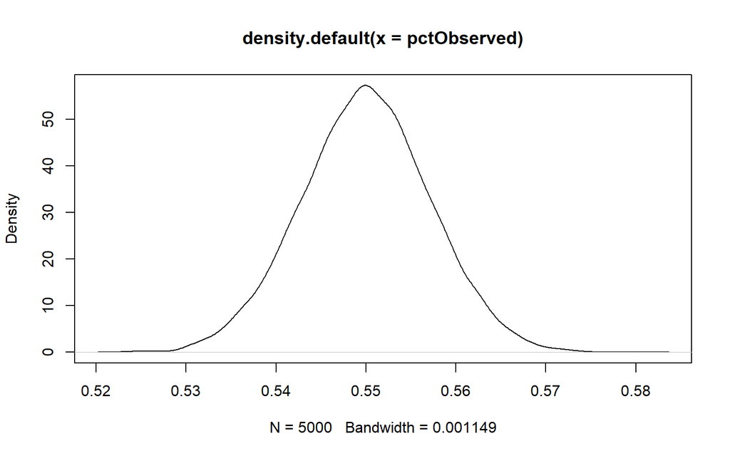

```r
#find CI for r under the M2 mechanism via simulation, using more accurate alpha_0

S = 5000
pctObserved = matrix(nrow = S, ncol = 1)

for (i in 1:S) {
  n = 5000
  pop_x = 0.7

  #simulate the x values
  X = rbinom(n, size = 1, pop_x)

  #simulate the y values
  beta_0 = log(0.5)
  beta_x = log(1.5)
  Y = rbinom(n, size = 1, prob = expit(beta_0 + beta_x * X))


  #simulate r values
  alpha_0 = -0.3583884
  alpha_y = 1.5
  M2 = rbinom(n, size = 1, prob = expit(alpha_0 + alpha_y * Y))

  #calculate percentage of observed values under M2
  pctObserved[i, 1] = mean(M2)

}

plot(density(pctObserved))
```

```r
mean(pctObserved)
```

```
## [1] 0.5499709
```

```r
quantile(pctObserved, c(0.025, 0.975))
```

```
##   2.5%  97.5%
## 0.5358 0.5638
```

This value of $\alpha_0$ gets us closer to the target missing rate of 45%. However, for the purposes of this simulation study, I will continue to use the value of $\alpha_0$ from the paper. This minor difference in the missing rate will not affect the conclusions of this simulation study.

## M3

```r
expit(1.35 - 1.5*0)*0.3 + expit(1.35 - 1.5*1)*0.7
```

```
## [1] 0.562038
```

By the conditional variance identity:
$$\begin{aligned}
Var[r] &= E[Var[r|x]] + Var[E[r|x]] \\
&= E[\text{expit}(1.35 - 1.5x)(1 - \text{expit}(1.35 - 1.5x))] + Var[\text{expit}(1.35 - 1.5x)] \\
&= E[\text{expit}(1.35 - 1.5x)] - E[(\text{expit}(1.35 - 1.5x))^2] + E[(\text{expit}(1.35 - 1.5x))^2] - (E[\text{expit}(1.35 - 1.5x)])^2 \\
&= E[\text{expit}(1.35 - 1.5x)] - (E[\text{expit}(1.35 - 1.5x)])^2 \\
&\approx 0.562 - 0.562^2 \\
&\approx 0.246
\end{aligned}$$

Again we can approximate a 95% confidence interval for $\bar r$, which is the proportion of missing $x$ values in the sample of 5000. That is, $0.562 \pm 1.96 \sqrt{0.246/5000} = (0.548, 0.576)$ is a 95% CI for $\bar r$.  
That is, for every 100 data sets of size 5000 generated randomly under M3, we would expect that 95 of them would contain between 54.8% and 57.6% observed $x$. We can check this with a simulation:

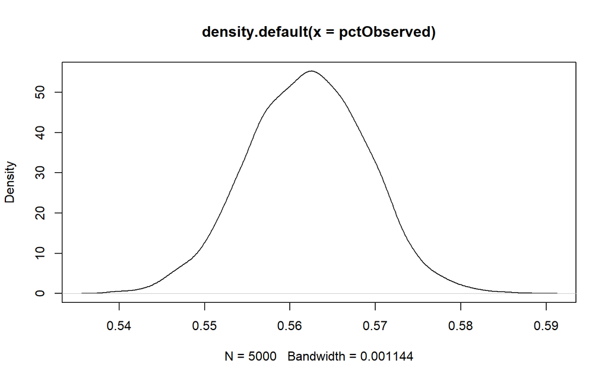

```r
#find CI for r under the M3 mechanism via simulation.

S = 5000
pctObserved = matrix(nrow = S, ncol = 1)

for (i in 1:S) {
  n = 5000
  pop_x = 0.7

  #simulate the x values
  X = rbinom(n, size = 1, pop_x)

  #simulate the y values
  beta_0 = log(0.5)
  beta_x = log(1.5)
  Y = rbinom(n, size = 1, prob = expit(beta_0 + beta_x * X))


  #simulation r values
  alpha_0 = 1.35
  alpha_x = -1.5
  M3 = rbinom(n, size = 1, prob = expit(alpha_0 + alpha_x * X))

  #calculate percentage of observed values under M2
  pctObserved[i, 1] = mean(M3)

}

plot(density(pctObserved))
```

```r
mean(pctObserved)
```

```
## [1] 0.5620333
```

```r
quantile(pctObserved, c(0.025, 0.975))
```

```
##     2.5%    97.5%
## 0.548195 0.575400
```

## M4

In M4, missingness in $x$ is related to the value of $y$ *and* the value of $x$. This is another MNAR mechanism. The table below summarizes the probabilities of observing $x$ conditioned on the values of $x$ and $y$:

| Actual x/Actual y | 0 | 1 |
| --- | --- | --- |
| 0 | $p(r = 1 \| x = 0, y = 0) = \text{expit}(0.75) \approx 0.679$ | $p(r = 1 \| x = 0, y = 1) = \text{expit}(0.75 + 1.5) \approx 0.905$ |
| 1 | $p(r = 1 \| x = 1, y = 0) = \text{expit}(0.75-1.5) \approx 0.321$ | $p(r = 1 \| x = 1, y = 1) = \text{expit}(0.75) \approx 0.679$ |

Under M4, $r|x,y \sim \text{Bernoulli}(p = \text{expit}(0.75 + 1.5y - 1.5x))$.
$$\begin{aligned}
E[r|x] &= \text{expit}(0.75 + 1.5y - 1.5x) \\
\end{aligned}$$
By the law of iterated expectations:
$$\begin{aligned}
E[r] &= E[E[r|x,y]] \\
&= E[\text{expit}(0.75 + 1.5y - 1.5x)] \\
&= \text{expit}(0.75 + 1.5*0 - 1.5*0)*p(x = 0, y = 0) + \text{expit}(0.75 + 1.5*0 - 1.5*1)*p(x = 1, y = 0) \\
& \quad+ \text{expit}(0.75 + 1.5*1 - 1.5*0)*p(x = 0, y = 1) + \text{expit}(0.75 + 1.5*1 - 1.5*1)*p(x = 1, y = 1)\\
&\approx 0.679*0.2 + 0.321*0.4 + 0.905*0.1 + 0.679*0.3\\
&\approx 0.558
\end{aligned}$$

```r
0.679 * 0.2 + 0.321 * 0.4 + 0.905 * 0.1 + 0.679 * 0.3
```

```
## [1] 0.5584
```

By the conditional variance identity:
$$\begin{aligned}
Var[r] &= E[Var[r|x, y]] + Var[E[r|x,y]] \\
&= E[\text{expit}(0.75 + 1.5y - 1.5x)(1 - \text{expit}(0.75 + 1.5y - 1.5x))] + Var[\text{expit}(0.75 + 1.5y - 1.5x)] \\
&= E[\text{expit}(0.75 + 1.5y - 1.5x)] - E[(\text{expit}(0.75 + 1.5y - 1.5x))^2] + E[(\text{expit}(0.75 + 1.5y - 1.5x))^2] - (E[\text{expit}(0.75 + 1.5y - 1.5x)])^2 \\
&= E[\text{expit}(0.75 + 1.5y - 1.5x)] - (E[\text{expit}(0.75 + 1.5y - 1.5x)])^2 \\
&\approx 0.558 - 0.558^2 \\
&\approx 0.247
\end{aligned}$$

Again we can approximate a 95% confidence interval for $\bar r$, which is the proportion of missing $x$ values in the sample of 5000. That is, $0.558 \pm 1.96 \sqrt{0.247/5000} = (0.544, 0.572)$ is a 95% CI for $\bar r$.  
That is, for every 100 data sets of size 5000 generated randomly under M4, we would expect that 95 of them would contain between 54.4% and 57.2% observed $x$. We can check this with a simulation:

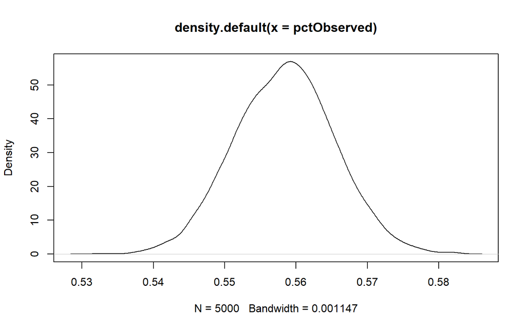

```r
#find CI for r under the M4 mechanism via simulation.

S = 5000
pctObserved = matrix(nrow = S, ncol = 1)

for (i in 1:S) {
  n = 5000
  pop_x = 0.7

  #simulate the x values
  X = rbinom(n, size = 1, pop_x)

  #simulate the y values
  beta_0 = log(0.5)
  beta_x = log(1.5)
  Y = rbinom(n, size = 1, prob = expit(beta_0 + beta_x * X))


  #simulate r values
  alpha_0 = 0.75
  alpha_y = 1.5
  alpha_x = -1.5
  M4 = rbinom(n, size = 1, prob = expit(alpha_0 + alpha_x*X + alpha_y*Y))

  #calculate percentage of observed values under M2
  pctObserved[i, 1] = mean(M4)

}

plot(density(pctObserved))
```

```r
mean(pctObserved)
```

```
## [1] 0.5584209
```

```r
quantile(pctObserved, c(0.025, 0.975))
```

```
##  2.5% 97.5%
## 0.545 0.572
```

Generate the response variable $r$ for each missingness scenario:

M1: $\text{logit}[p(r = 1 | x, y)] = \alpha_0$

```r
alpha_0 = log(0.55/0.45)
M1 = rbinom(n, size = 1, prob = expit(alpha_0))
```

M2: $\text{logit}[p(r = 1 | x, y)] = \alpha_0 + \alpha_y y$

```r
alpha_0 = -0.2
alpha_y = 1.5
M2 = rbinom(n, size = 1, prob = expit(alpha_0 + alpha_y * Y))
```

M3: $\text{logit}[p(r = 1 | x, y)] = \alpha_0 + \alpha_x x$

```r
alpha_0 = 1.35
alpha_x = -1.5
M3 = rbinom(n, size = 1, prob = expit(alpha_0 + alpha_x * X))
```

M4: $\text{logit}[p(r = 1 | x, y)] = \alpha_0 + \alpha_x x + \alpha_y y$

```r
alpha_0 = 0.75
alpha_y = 1.5
alpha_x = -1.5
M4 = rbinom(n, size = 1, prob = expit(alpha_0 + alpha_x * X + alpha_y * Y))
```

2. For $i = 1,...,5000$, set $x_i$ to missing if $r_i = 0$.

Create dataset for M1 condition:

```r
M1_data = completeData
M1_data$X[which(M1 == 0)] = NA
summary(M1_data)
```

```
##     X        Y
##  0   : 818   0:3043
##  1   :1899   1:1957
##  NA's:2283
```

Create dataset for M2 condition:

```r
M2_data = completeData
M2_data$X[which(M2 == 0)] = NA
summary(M2_data)
```

```
##     X        Y
##  0   : 911   0:3043
##  1   :1973   1:1957
##  NA's:2116
```

Create dataset for M3 condition:

```r
M3_data = completeData
M3_data$X[which(M3 == 0)] = NA
summary(M3_data)
```

```
##     X        Y
##  0   : 868   0:3043
##  1   :1936   1:1957
##  NA's:2196
```

Create dataset for M4 condition:

```r
M4_data = completeData
M4_data$X[which(M4 == 0)] = NA
summary(M4_data)
```

```
##     X        Y
##  0   : 873   0:3043
##  1   :1944   1:1957
##  NA's:2183
```

# Imputation using calibrated-$\delta$ and standard MI

4. Impute missing values in $x$ $M=50$ times using standard MI and calibrated-$\delta$ adjustment MI in turn. First let’s apply the calibrated-$\delta$ adjustment MI.

## Calibrated-$\delta$

This algorithm is described on page 797 of the paper. In this section, we will go step-by-step through this algorithm, which assumes the population distribution of $x$ is fixed and known. In the actual simulations, we will modify the code to handle the case where the population distribution is estimated from a sample.

1. Fit a logistic regression imputation model for $x$ conditional on $y$ to the complete records to obtain the maximum likelihood estimates of the imputation models’ parameters $\hat \theta$ and their asymptotic sampling variance $\hat U$.

```r
M1_log_reg = glm(X ~ Y,
                 data = M1_data,
                 family = "binomial",
                 na.action = na.exclude)

M1_summary = summary(M1_log_reg)

theta_hat = M1_summary$coefficients[, 1]
U_hat = M1_summary$coefficients[, 2] ^ 2
```

2. Draw new parameters $\tilde \theta$ from the large-sample normal approximation $N \left(\hat \theta, \hat U \right)$ of their posterior distribution, assuming non-informative priors.

```r
theta_0_tilde = rnorm(n = 1, mean = theta_hat[1], sd = sqrt(U_hat[1]))
theta_y_tilde = rnorm(n = 1, mean = theta_hat[2], sd = sqrt(U_hat[2]))
```

3. Draw a new probability of observing $x$, $\tilde p_r$, from the normal approximation $N \left(\hat p_r, \frac{\hat p_r (1 - \hat p_r)}{n} \right)$, where $\hat p_r$ is the sample proportion of the response indicator of $x$, $\hat p_r = \frac{n_{++}^{obs}}{n_{++}}$.  
   *[Note that the $++$ subscript is used in the same way the $..$ subscript is used in the regression setting.]*

```r
n = 5000
p_r_hat = mean(M1)
p_r_tilde = rnorm(n = 1, mean = p_r_hat, sd = sqrt(p_r_hat*(1 - p_r_hat)/n))
```

4. Draw a new probability of observed $x = 1$, $\tilde p_x$, from the normal approximation $N \left(\hat p_x, \frac{\hat p_x (1 - \hat p_x)}{n} \right)$, where $\hat p_x$ is the observed proportion of $x = 1$, $\hat p_x = \frac{n_{1+}^{obs}}{n_{++}^{obs}}$.

```r
#can use this expression to calculate p_x_hat:
#length(M1_data$X[which(M1_data$X == 1)])/length(M1_data$X[which(!is.na(M1_data$X))])

#but this way is shorter. We need the minus 1 because when R converts to numeric,
#the (0, 1) becomes (1, 2).
p_x_hat = mean(as.numeric(M1_data$X) - 1, na.rm = TRUE)
p_x_tilde = rnorm(n = 1, mean = p_x_hat, sd = sqrt(p_x_hat * (1 - p_x_hat)/n))
```

5. Derive the value of the calibrated $\delta$-adjustment from the equation

$$\frac{1}{n^{miss}} \sum_{i = 1}^{n^{mis}} \text{expit}[(\tilde \theta_0 + \delta) + \tilde \theta_y y_i] = \frac{p_x^{pop} - \tilde p_x \tilde p_r}{1 - \tilde p_r}$$

where $p_x^{pop}$ is the probability of $x = 1$ in the population.

```r
p_x_pop = 0.7

delta_equation = function(delta) {
  #extract only the rows of the data where x is missing
  missing_x = M1_data[which(is.na(M1_data$X)),]

  #calculate left hand side of the equation
  LHS = mean(expit((theta_0_tilde + delta) + theta_y_tilde * (as.numeric(missing_x$Y) - 1)))

  #calculate right hand side of the equation
  RHS = (p_x_pop - p_x_tilde * p_r_tilde) / (1 - p_r_tilde)

  #return function to minimize
  (LHS - RHS)^2
}

delta = optimize(delta_equation,
                 lower = -10,
                 upper = 10,
                 maximum = FALSE)$minimum
```

6. Fit the logistic regression imputation model for $x$ conditional on $y$ (in step 1) to the complete records with the intercept adjustment fixed to $\delta$ to obtain the maximum likelihood estimates of the imputation models’ parameters $\hat \theta$ and their asymptotic sampling variance $\hat U$.

Due to the invariance property of the MLE, we don’t need to refit a logistic regression model. The asymptotic posterior distribution is simply $N(\tilde \theta_0 + \delta, \tilde U_0)$.

7. Draw new parameters $\mathbf{\theta}$ from the large-sample normal approximation $N \left(\hat \theta, \hat U \right)$, assuming non-informative priors.

```r
theta_0 = rnorm(n = 1,
                mean = theta_hat[1] + delta,
                sd = sqrt(U_hat[1]))

theta_y = rnorm(n = 1,
                mean = theta_hat[2],
                sd = sqrt(U_hat[2]))
```

8. Draw imputed values for $x$ from the aforementioned logistic regression imputation model (specifically, $\text{logit}[p(x = 1|y)]=\theta_0 + \theta_y y$), using the newly drawn parameters $\mathbf{\theta}$ and calibrated-$\delta$ adjustment.

```r
M1_data  = M1_data %>%
  mutate(Probs = expit(theta_0 + theta_y * as.numeric(Y))) %>%
  mutate(Preds = rbinom(
    n = nrow(M1_data),
    size = 1,
    prob = Probs
  )) %>%
  mutate(X_complete = ifelse(is.na(X), Preds, as.numeric(X) - 1))

#have to subtract 1 when converting from factor to number; otherwise R uses 1 and 2.
```

Now we have to turn all this into a loop:

```r
#This function returns 1 completed set of X values
#incomplete_data argument must contain X and Y columns; p_pop is a known constant

CalibratedDelta = function(incomplete_data, p_x_pop) {
  #fit the logistic regression model on the complete data
  rx = !is.na(incomplete_data$X)
  design.mat = cbind(1, as.numeric(incomplete_data$Y) - 1)
  X = as.numeric(incomplete_data$X) - 1

  fit = glm.fit(x = design.mat[rx, ], y = X[rx],
                    family = binomial(link = logit))
  fit.sum = summary.glm(fit)

  #extract MLE of mean and variances for model params
  theta_hat = coef(fit)
  #U_hat = summary_log_reg$coefficients[, 2] ^ 2
  rv = t(chol(fit.sum$cov.unscaled))

  #draw new theta tilde params from the asymptotic distribution
  theta_tilde = theta_hat + rv %*% rnorm(ncol(rv))

  #draw new probability of observing x from the normal approximation
  n = nrow(incomplete_data)
  p_r_hat = mean(rx)
  p_r_tilde = rnorm(n = 1,
                    mean = p_r_hat,
                    sd = sqrt(p_r_hat * (1 - p_r_hat) / n))

  #draw new probability of observing x = 1 from the normal approximation
  p_x_hat = mean(as.numeric(incomplete_data$X[rx])) - 1
  p_x_tilde = rnorm(n = 1,
                    mean = p_x_hat,
                    sd = sqrt(p_x_hat * (1 - p_x_hat) / n))

  #derive the calibrated delta adjustment
  delta_equation = function(delta) {
    #extract only the rows of the data where x is missing
    missing_x = incomplete_data[which(is.na(incomplete_data$X)), ]

    #calculate left hand side of the equation
    LHS = mean(expit((theta_tilde[1] + delta) + theta_tilde[2] * (as.numeric(missing_x$Y) - 1)))

    #calculate right hand side of the equation
    RHS = (p_x_pop - p_x_tilde * p_r_tilde) / (1 - p_r_tilde)

    #return function to minimize
    (LHS - RHS)^2
  }

  delta = optimize(
    delta_equation,
    lower = -10,
    upper = 10,
    maximum = FALSE
  )$minimum

  theta_tilde[1] = theta_tilde[1] + delta

  theta = theta_tilde + rv %*% rnorm(ncol(rv))

  #try binomial draw instead
  p = expit(design.mat[!rx, ] %*% theta)
  vec = (runif(nrow(p)) <= p)
  vec[vec] = 1
  if (is.factor(incomplete_data$X)) {
    vec = factor(vec, c(0, 1), levels(incomplete_data$X))
  }

  incomplete_data$X_complete = incomplete_data$X
  incomplete_data$X_complete[!rx] = vec


  #fit logistic regression model to complete data
  log_reg_final = glm(
    Y ~ X_complete,
    data = incomplete_data,
    family = "binomial"
  )

  beta = summary(log_reg_final)$coefficients[, 1:2]
  return(beta)
}
```

Finally, we need a function to pool the different parameter estimates to obtain the final parameter and standard error estimates.

```r
Rubin = function(M, incomplete_data, p_x_pop){
  results = t(replicate(M,
                        as.vector(CalibratedDelta(incomplete_data, p_x_pop)),
                        simplify = "array"))
  Q = apply(results[,1:2], 2, mean)
  U = apply(results[,3:4]^2, 2, mean)  #mean variances from imputation
  B = apply(results[,1:2], 2, var)     #between imputation variances
  Tm = U + (1 + M^-1)*B      #combined variances
  return(list(Est = Q, SE = sqrt(Tm)))
}
```

## Standard Multiple Imputation

For the “standard” multiple imputation, I will use the `mice` package (with the “logreg” method).

```r
#impute data using traditional MI, using MICE
MI.Results = function(M, incomplete_data) {
  results = mice(data = incomplete_data,
                 m = M,
                 method = "logreg",
                 printFlag = FALSE)
  fit = with(data = results, exp = glm(Y ~ X, family = "binomial"))
  tbl = summary(pool(fit))
  return(list(Est = tbl$estimate, SE = tbl$std.error))
}
```

# Outline of Simulation Study

Simulate a missingness mechanism 2000 times

Each time:

- Fit using MICE
- Fit using calibrated-delta adjustment
- Fit using CRA
- Return estimates, standard errors, and the coverage of 95% confidence intervals

# Helper Functions

First, we need a function to generate the data:

```r
#generates a 5000x2 data frame of X and Y observations,
#based on the specifications in the paper.

CreateData = function() {
  n = 5000
  pop_x = 0.7

  #simulate the x values
  X = rbinom(n, size = 1, pop_x)

  #simulate the y values
  beta_0 = log(0.5)
  beta_x = log(1.5)
  Y = rbinom(n, size = 1, prob = expit(beta_0 + beta_x * X))

  #combine results into a data frame
  completeData = data.frame(X, Y)

  #convert X and Y columns to factors
  completeData$X = as.factor(completeData$X)
  completeData$Y = as.factor(completeData$Y)

  return(completeData)
}
```

Next, we create functions that will apply the desired missingness mechanism to the generated data sets:

```r
M1.Missingness.Mechanism = function(data) {
  n = nrow(data)
  alpha_0 = log(0.55 / 0.45)
  M1 = rbinom(n, size = 1, prob = expit(alpha_0))
  data$X[which(M1 == 0)] = NA
  return(data)
}

M2.Missingness.Mechanism = function(data) {
  n = nrow(data)
  alpha_0 = -0.2
  alpha_y = 1.5
  Y = as.numeric(data$Y) - 1
  M2 = rbinom(n, size = 1, prob = expit(alpha_0 + alpha_y * Y))
  data$X[which(M2 == 0)] = NA
  return(data)
}

M3.Missingness.Mechanism = function(data) {
  n = nrow(data)
  alpha_0 = 1.35
  alpha_x = -1.5
  X = as.numeric(data$X) - 1
  M3 = rbinom(n, size = 1, prob = expit(alpha_0 + alpha_x * X))
  data$X[which(M3 == 0)] = NA
  return(data)
}

M4.Missingness.Mechanism = function(data) {
  n = nrow(data)
  alpha_0 = 0.75
  alpha_y = 1.5
  alpha_x = -1.5
  X = as.numeric(data$X) - 1
  Y = as.numeric(data$Y) - 1
  M4 = rbinom(n,
              size = 1,
              prob = expit(alpha_0 + alpha_x * X + alpha_y * Y))
  data$X[which(M4 == 0)] = NA
  return(data)
}
```

This is a new version of the “Rubin” function created earlier that allows us to use population distributions obtained from a sample.

```r
Rubin_EstPopProp = function(M, incomplete_data, p_x_pop, n_ex) {
  results = t(replicate(M,
                        as.vector(CalibratedDelta_EstPopProp(incomplete_data, p_x_pop, n_ex)),
                        simplify = "array"))
  Q = apply(results[,1:2], 2, mean)
  U = apply(results[,3:4]^2, 2, mean)  #mean variances from imputation
  B = apply(results[,1:2], 2, var)     #between imputation variances
  Tm = U + (1 + M^-1)*B      #combined variances
  return(list(Est = Q, SE = sqrt(Tm)))
}
```

This is a new version of the “CalibratedDelta” function created earlier that allows us to use population distributions obtained from a sample.

```r
CalibratedDelta_EstPopProp = function(incomplete_data, p_x_pop_est, n_ex) {
  #fit the logistic regression model on the complete data
  rx = !is.na(incomplete_data$X)
  design.mat = cbind(1, as.numeric(incomplete_data$Y) - 1)
  X = as.numeric(incomplete_data$X) - 1

  fit = glm.fit(x = design.mat[rx, ], y = X[rx],
                    family = binomial(link = logit))
  fit.sum = summary.glm(fit)

  #extract MLE of mean and variances for model params
  theta_hat = coef(fit)
  #U_hat = summary_log_reg$coefficients[, 2] ^ 2
  rv = t(chol(fit.sum$cov.unscaled))

  #draw new theta tilde params from the asymptotic distribution
  theta_tilde = theta_hat + rv %*% rnorm(ncol(rv))

  #draw new probability of observing x from the normal approximation
  n = nrow(incomplete_data)
  p_r_hat = mean(rx)
  p_r_tilde = rnorm(n = 1,
                    mean = p_r_hat,
                    sd = sqrt(p_r_hat * (1 - p_r_hat) / n))

  #draw new probability of observing x = 1 from the normal approximation
  p_x_hat = mean(as.numeric(incomplete_data$X[rx])) - 1
  p_x_tilde = rnorm(n = 1,
                    mean = p_x_hat,
                    sd = sqrt(p_x_hat * (1 - p_x_hat) / n))

  #draw a p_x_pop from the asymptotic distribution
  p_x_pop = rnorm(n = 1,
                  mean = p_x_pop_est,
                  sd = sqrt(p_x_pop_est * (1 - p_x_pop_est)/n_ex))

  #derive the calibrated delta adjustment
  delta_equation = function(delta) {
    #extract only the rows of the data where x is missing
    missing_x = incomplete_data[which(is.na(incomplete_data$X)), ]

    #calculate left hand side of the equation
    LHS = mean(expit((theta_tilde[1] + delta) + theta_tilde[2] * (as.numeric(missing_x$Y) - 1)))

    #calculate right hand side of the equation
    RHS = (p_x_pop - p_x_tilde * p_r_tilde) / (1 - p_r_tilde)

    #return function to minimize
    (LHS - RHS)^2
  }

  delta = optimize(
    delta_equation,
    lower = -10,
    upper = 10,
    maximum = FALSE
  )$minimum

  #add the delta adjustment to the intercept
  theta_tilde[1] = theta_tilde[1] + delta

  theta = theta_tilde + rv %*% rnorm(ncol(rv))

  #do Bernoulli draw
  p = expit(design.mat[!rx, ] %*% theta)
  vec = (runif(nrow(p)) <= p)
  vec[vec] = 1
  if (is.factor(incomplete_data$X)) {
    vec = factor(vec, c(0, 1), levels(incomplete_data$X))
  }

  incomplete_data$X_complete = incomplete_data$X
  incomplete_data$X_complete[!rx] = vec


  #fit logistic regression model to complete data
  log_reg_final = glm(
    Y ~ X_complete,
    data = incomplete_data,
    family = "binomial"
  )

  beta = summary(log_reg_final)$coefficients[, 1:2]
  return(beta)
}
```

# Simulation Code

This function pulls together all the helper functions and generates the simulations. In this program:

- `S` is the number of simulated data sets (2000 in the paper)
- `M` is the number of imputations in standard and calibrated-$\delta$ MI (50 in the paper)
- `pop_x` is the probability that $x=1$, obtained from an external data set. The paper uses 70% for this value. This code will run 3 scenarios using this value: a) assuming `pop_x` is known from a census, b) assuming `pop_x` is estimated from a sample of size 10000, and c) assuming `pop_x` is estimated from a sample of size 1000.
- `missingness.mechanism` is either “M1”, “M2”, “M3”, or “M4” as defined in the paper

**This code takes approximately 7 $\times$ S seconds to run on my computer.** However, it’s highly parallelizable.

```r
#missingness.mechanism can take on "M1", "M2", "M3", or "M4"
sims = function(S, M, pop_x, missingness.mechanism) {
  sims_res = data.frame(
    Iter = integer(),
    Method = character(),
    est_beta_0 = double(),
    est_beta_1 = double(),
    SE_beta_0 = double(),
    SE_beta_1 = double(),
    stringsAsFactors = FALSE
  )

  print(paste("Starting", S, missingness.mechanism, "simulations at", Sys.time()))
  tictoc::tic()
  for (i in 1:S) {

    complete_data = CreateData()
    incomplete_data = switch(missingness.mechanism,
           "M1" = M1.Missingness.Mechanism(complete_data),
           "M2" = M2.Missingness.Mechanism(complete_data),
           "M3" = M3.Missingness.Mechanism(complete_data),
           "M4" = M4.Missingness.Mechanism(complete_data))

    #create data frame to hold results of this iteration
    iter_res = data.frame(
      Iter = integer(),
      Method = character(),
      est_beta_0 = double(),
      est_beta_1 = double(),
      SE_beta_0 = double(),
      SE_beta_1 = double(),
      stringsAsFactors = FALSE
    )
    #full data
    log_reg_full = glm(Y ~ X,
                       data = complete_data,
                       family = "binomial")
    Full_Est = log_reg_full$coefficients
    Full_SE = coef(summary(log_reg_full))[, "Std. Error"]
    iter_res[1,] = c(i, "Full data", Full_Est, Full_SE)

    #CRA on incomplete data
    log_reg_CRA = glm(Y ~ X,
                      data = incomplete_data,
                      family = "binomial",
                      na.action = na.exclude)
    CRA_Est = log_reg_CRA$coefficients
    CRA_SE = coef(summary(log_reg_CRA))[, "Std. Error"]
    iter_res = rbind(iter_res, c(i, "CCA", CRA_Est, CRA_SE))

    #Standard MI (with MICE)
    MI_Res = MI.Results(M, incomplete_data)
    iter_res = rbind(iter_res, c(i, "Standard MI", unlist(MI_Res)))

    #Calibrated Delta method
    CalibratedDeltaRes = Rubin(M, incomplete_data, pop_x)
    iter_res = rbind(iter_res, c(i, "Calibrated Delta", unlist(CalibratedDeltaRes)))

    #Calibrated Delta with estimated population parameter, pop size = 10,000
    #get p_hat_x_pop for given population size
    p_hat_x_prop = mean(rbinom(n = 10000, size = 1, prob = pop_x))
    CalibratedDeltaRes_EstPopProp = Rubin_EstPopProp(M, incomplete_data,
                                                     p_hat_x_prop, 10000)
    iter_res = rbind(iter_res, c(i, "Calibrated Delta 10000",
                                 unlist(CalibratedDeltaRes_EstPopProp)))

    #Calibrated Delta with estimated population parameter, pop size = 1000
    #get p_hat_x_pop for given population size
    p_hat_x_prop = mean(rbinom(n = 1000, size = 1, prob = pop_x))
    CalibratedDeltaRes_EstPopProp = Rubin_EstPopProp(M, incomplete_data,
                                                     p_hat_x_prop, 1000)
    iter_res = rbind(iter_res, c(i, "Calibrated Delta 1000",
                                 unlist(CalibratedDeltaRes_EstPopProp)))
    iter_res = iter_res %>%
      mutate_at(c("est_beta_0", "est_beta_1", "SE_beta_0", "SE_beta_1"), as.numeric)
    sims_res = rbind(sims_res, iter_res)
    #i = 2
    if ((i %% 200) == 0) {
      print(paste(i, "of", S, "simulations complete at", Sys.time()))
    }
  }
  tictoc::toc()
  return(sims_res)
}

M1_df = sims(2000, 50, 0.7, "M1")

M2_df = sims(2000, 50, 0.7, "M2")

M3_df = sims(2000, 50, 0.7, "M3")

M4_df = sims(2000, 50, 0.7, "M4")
```

# Summary of Results

Add column that indicates simulation type:

```r
M1_df$MissingnessMechanism = "M1"
M2_df$MissingnessMechanism = "M2"
M3_df$MissingnessMechanism = "M3"
M4_df$MissingnessMechanism = "M4"
```

Combine data frames:

```r
AllSims = rbind(M1_df, M2_df, M3_df, M4_df)
AllSims$MissingnessMechanism = as.factor(AllSims$MissingnessMechanism)
summary(AllSims)
```

```
##        X              Iter                           Method
##  Min.   :    1   Min.   :   1.0   Calibrated Delta      :8000
##  1st Qu.: 3001   1st Qu.: 500.8   Calibrated Delta 1000 :8000
##  Median : 6000   Median :1000.5   Calibrated Delta 10000:8000
##  Mean   : 6000   Mean   :1000.5   CCA                   :8000
##  3rd Qu.: 9000   3rd Qu.:1500.2   Full data             :8000
##  Max.   :12000   Max.   :2000.0   Standard MI           :8000
##    est_beta_0         est_beta_1        SE_beta_0         SE_beta_1
##  Min.   :-1.16322   Min.   :0.02629   Min.   :0.04995   Min.   :0.06265
##  1st Qu.:-0.73523   1st Qu.:0.35654   1st Qu.:0.05924   1st Qu.:0.07667
##  Median :-0.68547   Median :0.41295   Median :0.06404   Median :0.08103
##  Mean   :-0.66509   Mean   :0.44388   Mean   :0.06495   Mean   :0.08227
##  3rd Qu.:-0.63386   3rd Qu.:0.47707   3rd Qu.:0.07081   3rd Qu.:0.08860
##  Max.   : 0.08681   Max.   :1.16751   Max.   :0.09912   Max.   :0.13314
##  MissingnessMechanism
##  M1:12000
##  M2:12000
##  M3:12000
##  M4:12000
##
##
```

Add variables indicating if the true $\beta$ parameters are within 1.95 standard errors of the estimated paramaters.

```r
AllSims = AllSims %>%
  mutate(beta_0_covered = ifelse((beta_0 >= est_beta_0 - 1.95 * SE_beta_0) & (beta_0 <= est_beta_0 + 1.95 * SE_beta_0), 1, 0)) %>%
  mutate(beta_x_covered = ifelse((beta_x >= est_beta_1 - 1.95 * SE_beta_1) & (beta_x <= est_beta_1 + 1.95 * SE_beta_1), 1, 0))

summary(AllSims$beta_0_covered)
```

```
##    Min. 1st Qu.  Median    Mean 3rd Qu.    Max.
##  0.0000  1.0000  1.0000  0.8295  1.0000  1.0000
```

Create a summary table:

```r
AllSims$bias_beta_0 = AllSims$est_beta_0 - beta_0
AllSims$bias_beta_x = AllSims$est_beta_1 - beta_x

summary = AllSims %>%
  group_by(MissingnessMechanism, Method) %>%
  summarize(beta_0_hat = mean(est_beta_0),
            beta_x_hat = mean(est_beta_1),
            avg_bias_beta_0 = mean(bias_beta_0),
            avg_bias_beta_x = mean(bias_beta_x),
            avg_SE_beta_0 = mean(SE_beta_0),
            avg_SE_beta_x = mean(SE_beta_1),
            emp_SE_beta_0 = sd(est_beta_0),
            emp_SE_beta_x = sd(est_beta_1),
            coverage_beta_0 = mean(beta_0_covered),
            coverage_beta_x = mean(beta_x_covered))
kable(summary)
```

| MissingnessMechanism | Method | beta_0_hat | beta_x_hat | avg_bias_beta_0 | avg_bias_beta_x | avg_SE_beta_0 | avg_SE_beta_x | emp_SE_beta_0 | emp_SE_beta_x | coverage_beta_0 | coverage_beta_x |
| --- | --- | --- | --- | --- | --- | --- | --- | --- | --- | --- | --- |
| M1 | Calibrated Delta | -0.6926522 | 0.4045784 | 0.0004950 | -0.0008867 | 0.0750583 | 0.0960246 | 0.0707522 | 0.0897287 | 0.9605 | 0.9610 |
| M1 | Calibrated Delta 1000 | -0.6913816 | 0.4030814 | 0.0017656 | -0.0023837 | 0.0749220 | 0.0955923 | 0.0706169 | 0.0892461 | 0.9600 | 0.9645 |
| M1 | Calibrated Delta 10000 | -0.6924630 | 0.4043114 | 0.0006842 | -0.0011537 | 0.0750474 | 0.0959783 | 0.0709737 | 0.0899896 | 0.9605 | 0.9580 |
| M1 | CCA | -0.6938537 | 0.4047761 | -0.0007065 | -0.0006890 | 0.0739659 | 0.0871420 | 0.0755838 | 0.0891578 | 0.9450 | 0.9405 |
| M1 | Full data | -0.6938909 | 0.4064925 | -0.0007437 | 0.0010274 | 0.0548259 | 0.0645979 | 0.0551334 | 0.0659118 | 0.9465 | 0.9455 |
| M1 | Standard MI | -0.6931007 | 0.4051396 | 0.0000465 | -0.0003255 | 0.0694435 | 0.0874912 | 0.0706650 | 0.0895734 | 0.9430 | 0.9390 |
| M2 | Calibrated Delta | -0.6917994 | 0.4021737 | 0.0013478 | -0.0032914 | 0.0676823 | 0.0864175 | 0.0651756 | 0.0816477 | 0.9570 | 0.9655 |
| M2 | Calibrated Delta 1000 | -0.6885046 | 0.3995582 | 0.0046426 | -0.0059069 | 0.0758699 | 0.1025933 | 0.0726290 | 0.0972795 | 0.9545 | 0.9545 |
| M2 | Calibrated Delta 10000 | -0.6912981 | 0.4016429 | 0.0018491 | -0.0038222 | 0.0686305 | 0.0883069 | 0.0658001 | 0.0834133 | 0.9560 | 0.9605 |
| M2 | CCA | -0.1349733 | 0.4025577 | 0.5581739 | -0.0029074 | 0.0690855 | 0.0820593 | 0.0689074 | 0.0817048 | 0.0000 | 0.9505 |
| M2 | Full data | -0.6925641 | 0.4031501 | 0.0005831 | -0.0023150 | 0.0547819 | 0.0645678 | 0.0546536 | 0.0643856 | 0.9465 | 0.9540 |
| M2 | Standard MI | -0.6921118 | 0.4028163 | 0.0010354 | -0.0026488 | 0.0652084 | 0.0823416 | 0.0654901 | 0.0819641 | 0.9445 | 0.9505 |
| M3 | Calibrated Delta | -0.6924868 | 0.4064214 | 0.0006604 | 0.0009563 | 0.0629629 | 0.0776363 | 0.0610990 | 0.0745655 | 0.9570 | 0.9580 |
| M3 | Calibrated Delta 1000 | -0.6915441 | 0.4052125 | 0.0016031 | -0.0002526 | 0.0630283 | 0.0778721 | 0.0610312 | 0.0747072 | 0.9590 | 0.9605 |
| M3 | Calibrated Delta 10000 | -0.6925212 | 0.4064344 | 0.0006260 | 0.0009693 | 0.0629865 | 0.0776804 | 0.0607818 | 0.0742984 | 0.9575 | 0.9610 |
| M3 | CCA | -0.6932045 | 0.4064643 | -0.0000573 | 0.0009992 | 0.0615006 | 0.0794172 | 0.0608807 | 0.0791543 | 0.9555 | 0.9505 |
| M3 | Full data | -0.6914689 | 0.4051671 | 0.0016783 | -0.0002980 | 0.0547846 | 0.0645639 | 0.0548347 | 0.0649425 | 0.9455 | 0.9440 |
| M3 | Standard MI | -0.6429223 | 0.4063399 | 0.0502248 | 0.0008748 | 0.0559973 | 0.0797096 | 0.0560188 | 0.0793800 | 0.8410 | 0.9460 |
| M4 | Calibrated Delta | -0.6952522 | 0.4080676 | -0.0021050 | 0.0026025 | 0.0625325 | 0.0782684 | 0.0608311 | 0.0757760 | 0.9510 | 0.9560 |
| M4 | Calibrated Delta 1000 | -0.6915466 | 0.4054335 | 0.0016006 | -0.0000316 | 0.0754247 | 0.1026120 | 0.0748507 | 0.1014776 | 0.9460 | 0.9560 |
| M4 | Calibrated Delta 10000 | -0.6945135 | 0.4072215 | -0.0013663 | 0.0017564 | 0.0638517 | 0.0809029 | 0.0621811 | 0.0784944 | 0.9530 | 0.9580 |
| M4 | CCA | -0.4097612 | 0.8736163 | 0.2833859 | 0.4681511 | 0.0607307 | 0.0789455 | 0.0600355 | 0.0788751 | 0.0035 | 0.0000 |
| M4 | Full data | -0.6958035 | 0.4087454 | -0.0026563 | 0.0032802 | 0.0548163 | 0.0645930 | 0.0544512 | 0.0642703 | 0.9490 | 0.9470 |
| M4 | Standard MI | -0.9225581 | 0.8737293 | -0.2294109 | 0.4682642 | 0.0556121 | 0.0791095 | 0.0554461 | 0.0789743 | 0.0150 | 0.0000 |

# Plots

The plots created in this section are inspired by the Stata plots on pages 798 and 800 of the paper. Separate plots are created for the bias, standard errors, and coverage of confidence intervals.

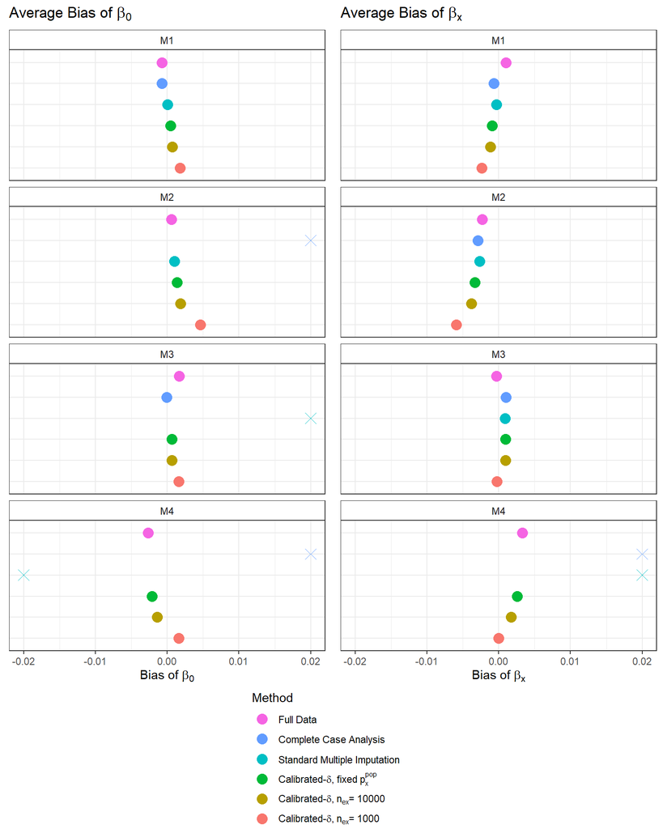

```r
#set the order in which we want the methods to appear
lvls = c(
  "Full data",
  "CCA",
  "Standard MI",
  "Calibrated Delta",
  "Calibrated Delta 10000",
  "Calibrated Delta 1000"
)

#apply the method ordering to the summary table
summary$Method = factor(summary$Method,
                        levels = c("Calibrated Delta 1000",
                                   "Calibrated Delta 10000",
                                   "Calibrated Delta",
                                   "Standard MI",
                                   "CCA",
                                   "Full data"))

#create list of method labels to use for the plots
labs = c(expression(paste("Calibrated-", delta, ", ", n[ex], '= 1000')),
         expression(paste("Calibrated-", delta, ", ", n[ex], '= 10000')),
         expression(paste("Calibrated-", delta, ', fixed ', p[x]^{pop})),
         "Standard Multiple Imputation",
         "Complete Case Analysis",
         "Full Data")

beta_0_bias = summary %>%
  mutate(OutOfBounds = abs(avg_bias_beta_0) > 0.02,
         avg_bias_beta_0 = if_else(OutOfBounds, 0.02 * sign(avg_bias_beta_0), avg_bias_beta_0)) %>%
  ggplot(aes(y = Method, x = avg_bias_beta_0, color = Method, shape = OutOfBounds)) +
  geom_point(size = 4) +
  xlab(expression(paste("Bias of ", beta[0]))) +
  scale_x_continuous(limits = c(-0.02, 0.02)) +
  labs(title = expression(paste("Average Bias of ", beta[0]))) +
  scale_color_discrete(labels = labs) +
  scale_shape_manual(values = c(19, 4), guide = "none") +
  theme_bw() +
  theme(legend.position="bottom",
        legend.direction="vertical",
        legend.text.align = 0,
        axis.text.y = element_blank(),
        axis.title.y = element_blank(),
        axis.ticks.y = element_blank(),
        strip.background =element_rect(fill="white")) +
  guides(color = guide_legend(reverse = TRUE)) +
  facet_wrap(~MissingnessMechanism, ncol = 1)

beta_x_bias = summary %>%
   mutate(OutOfBounds = abs(avg_bias_beta_x) > 0.02,
         avg_bias_beta_x = if_else(OutOfBounds, 0.02 * sign(avg_bias_beta_x), avg_bias_beta_x)) %>%
  ggplot(aes(y = Method, x = avg_bias_beta_x, color = Method, shape = OutOfBounds)) +
  geom_point(size = 4) +
  xlab(expression(paste("Bias of ", beta[x]))) +
  scale_x_continuous(limits = c(-0.02, 0.02)) +
  labs(title = expression(paste("Average Bias of ", beta[x]))) +
  scale_color_discrete(labels = labs) +
  scale_shape_manual(values = c(19, 4), guide = "none") +
  theme_bw() +
  theme(legend.position="bottom",
        legend.direction="vertical",
        legend.text.align = 0,
        axis.text.y = element_blank(),
        axis.title.y = element_blank(),
        axis.ticks.y = element_blank(),
        strip.background =element_rect(fill="white")) +
  guides(color = guide_legend(reverse = TRUE)) +
  facet_wrap(~MissingnessMechanism, ncol = 1)

# arrange the three plots in a single row
prow = plot_grid(beta_0_bias + theme(legend.position="none"),
           beta_x_bias + theme(legend.position="none"),
           align = 'vh',
           hjust = -1,
           nrow = 1
           )


# extract the legend from one of the plots
# (clearly the whole thing only makes sense if all plots
# have the same legend, so we can arbitrarily pick one.)
legend_b = get_legend(beta_0_bias + theme(legend.position="bottom"))

# add the legend underneath the row we made earlier. Give it 10% of the height
# of one plot (via rel_heights).
p = plot_grid( prow, legend_b, ncol = 1, rel_heights = c(1, .2))
p
```

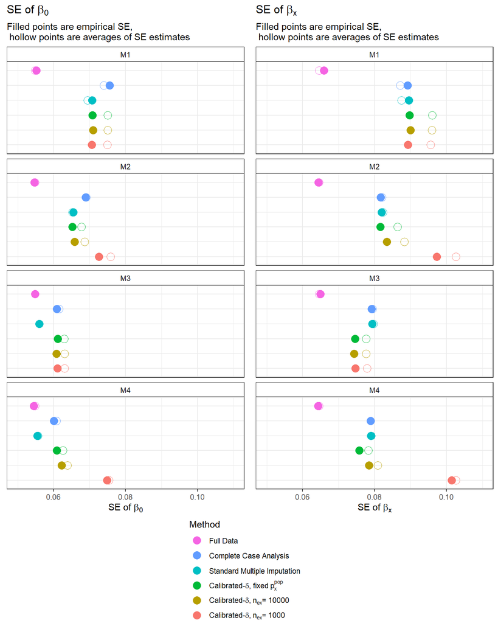

```r
###########################

beta_0_SE_plot = summary %>%
  ggplot(aes(y = Method, x = avg_SE_beta_0, color = Method)) +
  geom_point(shape = 1, size = 4) +
  geom_point(data = summary,
             aes(y = Method, x = emp_SE_beta_0, color = Method),
             shape = 16, size = 4) +
  xlab(expression(paste("SE of ", beta[0]))) +
  scale_x_continuous(limits = c(0.05, 0.11)) +
  labs(title = expression(paste("SE of ", beta[0])),
       subtitle = "Filled points are empirical SE, \n hollow points are averages of SE estimates") +
  scale_color_discrete(labels = labs) +
  theme_bw() +
  theme(legend.position="bottom",
        legend.direction="vertical",
        legend.text.align = 0,
        axis.text.y = element_blank(),
        axis.title.y = element_blank(),
        axis.ticks.y = element_blank(),
        strip.background =element_rect(fill="white")) +
  guides(color = guide_legend(reverse = TRUE)) +
  facet_wrap(~MissingnessMechanism, ncol = 1)

###########################

beta_x_SE_plot = summary %>%
  ggplot(aes(y = Method, x = avg_SE_beta_x, color = Method)) +
  geom_point(shape = 1, size = 4) +
  geom_point(data = summary,
             aes(y = Method, x = emp_SE_beta_x, color = Method),
             shape = 16, size = 4) +
  xlab(expression(paste("SE of ", beta[x]))) +
  scale_x_continuous(limits = c(0.05, 0.11)) +
  labs(title = expression(paste("SE of ", beta[x])),
       subtitle = "Filled points are empirical SE, \n hollow points are averages of SE estimates") +
  scale_color_discrete(labels = labs) +
  theme_bw() +
  theme(legend.position="bottom",
        legend.direction="vertical",
        legend.text.align = 0,
        axis.text.y = element_blank(),
        axis.title.y = element_blank(),
        axis.ticks.y = element_blank(),
        strip.background =element_rect(fill="white")) +
  guides(color = guide_legend(reverse = TRUE)) +
  facet_wrap(~MissingnessMechanism, ncol = 1)

# arrange the three plots in a single row
prow = plot_grid(beta_0_SE_plot + theme(legend.position="none"),
           beta_x_SE_plot + theme(legend.position="none"),
           align = 'vh',
           #labels = c("A", "B", "C"),
           hjust = -1,
           nrow = 1
           )

# extract the legend from one of the plots
# (clearly the whole thing only makes sense if all plots
# have the same legend, so we can arbitrarily pick one.)
legend_b = get_legend(beta_0_SE_plot + theme(legend.position="bottom"))

# add the legend underneath the row we made earlier. Give it 10% of the height
# of one plot (via rel_heights).
p = plot_grid( prow, legend_b, ncol = 1, rel_heights = c(1, .2))
p
```

```r
#ggsave("SE Plot.jpg", plot = p, dpi = 320, height = 10, units = "in")
```

Get 95% CI coverage probabilities:

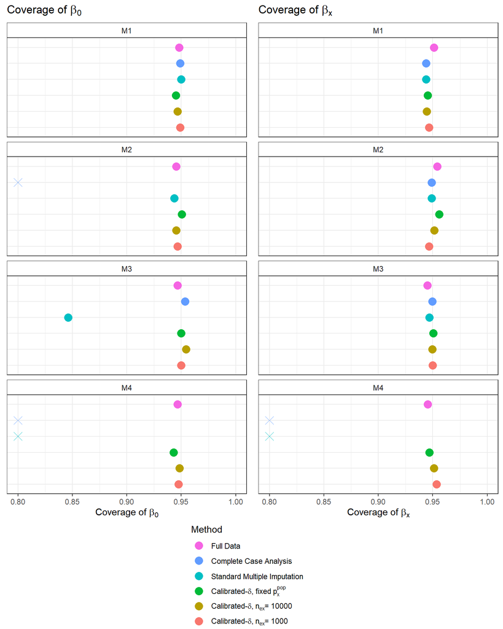

```r
#Get 95% empirical CI for each iteration

CIs = left_join(AllSims, summary, by = c("MissingnessMechanism", "Method"))

CIs = CIs %>%
  mutate(beta_0_covered = ifelse((beta_0 >= est_beta_0 - 1.95 * emp_SE_beta_0) & (beta_0 <= est_beta_0 + 1.95 * emp_SE_beta_0), 1, 0)) %>%
  mutate(beta_x_covered = ifelse((beta_x >= est_beta_1 - 1.95 * emp_SE_beta_x) & (beta_x <= est_beta_1 + 1.95 * emp_SE_beta_x), 1, 0))


CIs$Method = factor(
  CIs$Method,
  levels = c(
    "Calibrated Delta 1000",
    "Calibrated Delta 10000",
    "Calibrated Delta",
    "Standard MI",
    "CCA",
    "Full data"
  )
)


beta_0_coverage = CIs %>%
  group_by(MissingnessMechanism, Method) %>%
  summarize(coverage_beta_0 = mean(beta_0_covered)) %>%
  mutate(OutOfBounds =  coverage_beta_0 < 0.8,
         coverage_beta_0 = if_else(OutOfBounds, 0.8, coverage_beta_0)) %>%
  ggplot(aes(y = Method, x = coverage_beta_0, color = Method, shape = OutOfBounds)) +
  geom_point(size = 4) +
  xlab(expression(paste("Coverage of ", beta[0]))) +
  scale_x_continuous(limits = c(0.8, 1)) +
  labs(title = expression(paste("Coverage of ", beta[0]))) +
  scale_color_discrete(labels = labs) +
  scale_shape_manual(values = c(19, 4), guide = "none") +
  theme_bw() +
  theme(legend.position="bottom",
        legend.direction="vertical",
        legend.text.align = 0,
        axis.text.y = element_blank(),
        axis.title.y = element_blank(),
        axis.ticks.y = element_blank(),
        strip.background =element_rect(fill="white")) +
  guides(color = guide_legend(reverse = TRUE)) +
  facet_wrap(~MissingnessMechanism, ncol = 1)
beta_x_coverage = CIs %>%
  group_by(MissingnessMechanism, Method) %>%
  summarize(coverage_beta_x = mean(beta_x_covered)) %>%
  mutate(OutOfBounds =  coverage_beta_x < 0.8,
         coverage_beta_x = if_else(OutOfBounds, 0.8, coverage_beta_x)) %>%
  ggplot(aes(y = Method, x = coverage_beta_x, color = Method, shape = OutOfBounds)) +
  geom_point(size = 4) +
  xlab(expression(paste("Coverage of ", beta[x]))) +
  scale_x_continuous(limits = c(0.8, 1)) +
  labs(title = expression(paste("Coverage of ", beta[x]))) +
  scale_color_discrete(labels = labs) +
  scale_shape_manual(values = c(19, 4), guide = "none") +
  theme_bw() +
  theme(legend.position="bottom",
        legend.direction="vertical",
        legend.text.align = 0,
        axis.text.y = element_blank(),
        axis.title.y = element_blank(),
        axis.ticks.y = element_blank(),
        strip.background =element_rect(fill="white")) +
  guides(color = guide_legend(reverse = TRUE)) +
  facet_wrap(~MissingnessMechanism, ncol = 1)
# arrange the three plots in a single row
prow = plot_grid(beta_0_coverage + theme(legend.position="none"),
           beta_x_coverage + theme(legend.position="none"),
           align = 'vh',
           #labels = c("A", "B", "C"),
           hjust = -1,
           nrow = 1
           )

# extract the legend from one of the plots
# (clearly the whole thing only makes sense if all plots
# have the same legend, so we can arbitrarily pick one.)
legend_b = get_legend(beta_0_coverage + theme(legend.position="bottom"))

# add the legend underneath the row we made earlier. Give it 10% of the height
# of one plot (via rel_heights).
p = plot_grid( prow, legend_b, ncol = 1, rel_heights = c(1, .2))
p
```